Yu Dong En P1936348 EP_0302_02

**List of links of all datasets used:**  
https://data.worldbank.org/indicator/NY.GDP.MKTP.CD(GDP per capita),  
https://data.worldbank.org/indicator/IT.NET.USER.ZS(How many internet users)  
https://ourworldindata.org/internet,(How many internet users does each country have?)  
https://worldpopulationreview.com/country-rankings/internet-speeds-by-country(Internet Speed by Country)  
https://data.gov.sg/dataset/individual-internet-usage(contains 2 Datasets),  
https://data.gov.sg/dataset/internet-connection-at-home-by-type,  
https://data.gov.sg/dataset/number-of-infocomm-jobs-employed-and-vacancies,  
https://data.gov.sg/dataset/universities-intake-enrolment-and-graduates-by-course,  
https://data.gov.sg/dataset/domestic-revenue-of-infocomm-industry-by-market-segment,  
https://data.gov.sg/dataset/export-revenue-of-infocomm-industry-by-market-segment,  
https://data.gov.sg/dataset/total-mobile-phone-subscriptions,  
https://data.gov.sg/dataset/usage-of-mobile-devices-for-media-activities

# The Influence of the Internet on the World (With a focus on Singapore)

The Invention of the Internet and its subsequent commercialization has been influencing every part of our lives.  
From https://www.brookings.edu/research/the-economy-and-the-internet-what-lies-ahead/#:~:text=The%20Internet%20will%20produce%20significant,faster%20growth%20in%20living%20standards.:  
The Internet will produce significant cost savings in many sectors of the economy, resulting in faster productivity growth. It will also produce lower prices for consumers, resulting in faster growth in living standards.

The Internet should also generate a variety of benefits to users, in their capacities as consumers and citizens, that are not easily quantified but nonetheless real: savings in time, added convenience, and products and services tailored specifically to them. In an era when consumers are aware more than ever that “time is money, these benefits to many may be more noticeable and appreciated than the numbers that economists like to count.

This study will go into how the rise of Internet and some various sub-breakthroughs affects Nations and their population such as  
-Is there a trend between having a high GDP and high internet usage?  
-When exactly did the internet go 'mainstream' in 1st World Countries?  
-When did the internet go 'mainstream' in Most Developed Countries/First world countries?  
-How does high HDI correlate high internet speed and does is there a big difference between high and low HDI?  
-Which age group uses more internet and when was the period with the most internet usage growth.  
-What type of broadband connection became the most dominant at what time and why?  
-How has the Internet changed the Singaporean Economy specifically the Info-Comm Industry.  
-How has the rise of the internet affected the amount of mobile phones, and what might be the reason why?  
-What do Singaporeans do with their mobile phones, how has that changed over the years and what generation uses mobile phones the most.  
This study's focus is on 1980 onwards as the internet before then was not meant for consumers.  
It will focus specifically on Singapore.

The Rise of the internet as a daily part of our lives began around the 1990s. Its rise along with mobile phones allowed us to communicate with anyone, anywhere at any time.  
Hypothetically, the internet would provide an immense advantage to the nation's businesses and productivity, specifically the GDP per Capita, due to having instant communication to do trade with others as well as increasing productivity. Using a Scatterplot graph, I will try and answer the question,  
**Is there a trend between having a high GDP and high internet usage?**  
I will highlight Prominent Nations and Singapore to provide a bench mark.

The Datasets below contain the total GDP per capita of all the countries in the world (Including some areas that are grouped together, however, those are dropped from the data.) and the percentage of people using internet in the world. Both datasets include different years starting from 1960 to the present day. However, we will be focusing on 2017.

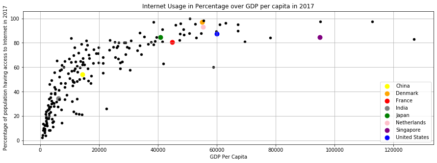

```python
import pandas as pd
import numpy as np
import matplotlib.pyplot as plt

#These are not countries, so i will drop them to not affect our data.
worldDatabank_Drop_Rows = ["World","High income","OECD members","Post-demographic dividend","IDA & IBRD total","Low & middle income","Middle income","IBRD only","East Asia & Pacific","Upper middle income","Europe & Central Asia","North America","Late-demographic dividend","East Asia & Pacific (excluding high income)","East Asia & Pacific (IDA & IBRD countries)","European Union","Euro area","Early-demographic dividend","Lower middle income","Latin America & Caribbean","Latin America & the Caribbean (IDA & IBRD countries)","Latin America & Caribbean (excluding high income)","Europe & Central Asia (IDA & IBRD countries)","South Asia","South Asia (IDA & IBRD)","Middle East & North Africa","Europe & Central Asia (excluding high income)","Arab World","IDA total","Sub-Saharan Africa","Sub-Saharan Africa (IDA & IBRD countries)","Sub-Saharan Africa (excluding high income)","Korea, Rep.","Fragile and conflict affected situations","Central Europe and the Baltics","Middle East & North Africa (excluding high income)","Middle East & North Africa (IDA & IBRD countries)","Pre-demographic dividend","IDA only","Heavily indebted poor countries (HIPC)","Low income","Other small states","Small states","Caribbean small states","Pacific island small states"]
focusCountries = ['China','United States','Japan','Singapore','Denmark','Netherlands','France','India']

#Reading data
#The skiprows and header parameters are due to the header and other useless information present in the .csv file.
df_total_gdp_per_capita = pd.read_csv('total_GDP_per_capita.csv',skiprows=[1,2],header=1).set_index("Country Name").drop(worldDatabank_Drop_Rows)
df_global_internet = pd.read_csv('internet_usage_global.csv',error_bad_lines=False).set_index("Country Name")

#Cleaning the data, then sorting it to get only 2017s data
#Here i drop the 2 columns that are not needed and the countries above, then i get only 2017s data
df_global_internet_sort = df_global_internet.drop(columns=["Indicator Name","Indicator Code"]).drop(worldDatabank_Drop_Rows).loc[:,'2017']
df_total_gdp_per_capita_sort = df_total_gdp_per_capita.drop(columns=["Indicator Name","Indicator Code"]).loc[:,'2017']

#Setting
plt.figure(figsize=(15, 5))
plt.grid()
plt.xlabel("GDP Per Capita")
plt.ylabel("Percentage of population having access to Internet in 2017")
plt.title("Internet Usage in Percentage over GDP per capita in 2017")

#This sets a new coloumn and with the default values
df_total_gdp_per_capita['color'] = 'Black'
df_total_gdp_per_capita['size'] = 20
df_total_gdp_per_capita['label'] = None

#These following statements only select those focus i want to focus on.
#This makes sure only the important countries are labelled.
df_total_gdp_per_capita.loc[df_total_gdp_per_capita.index.isin(focusCountries),'label'] = df_total_gdp_per_capita[df_total_gdp_per_capita.index.isin(focusCountries)].index

#This only colors the important countries
df_total_gdp_per_capita.loc[df_total_gdp_per_capita.index.isin(focusCountries),'color'] = ["Yellow","Orange","Red","Grey","Green","Pink","Purple","Blue"]

#This makes the important countries bigger
df_total_gdp_per_capita.loc[df_total_gdp_per_capita.index.isin(focusCountries),'size'] = 80

for label in np.arange(0,df_total_gdp_per_capita_sort.to_numpy().size,1):
    #The color takes from the Color Column
    #The label takes from the Label Column, if default there is no label
    #The size takes from the size column.
    plt.scatter(df_total_gdp_per_capita_sort[label],df_global_internet_sort[label],label=df_total_gdp_per_capita.loc[:,'label'][label],c=df_total_gdp_per_capita.loc[:,'color'][label],s=df_total_gdp_per_capita.loc[:,'size'][label])

plt.legend()
plt.show()
```

As we can see here, there is an obvious increasing Trend between high GDP Per Capita and a high percentage of the population having access to the internet.  
Going by one website's definition:https://www.investopedia.com/updates/top-developing-countries/  
"Many highly developed countries, including the United States, have high per capita GDPs of $40,000 or above."  
Most countries in this spectrum have at least >80% of the population having access to the internet  
This means that countries which have good internet infrastructure are overall more efficent and productive(such as Singapore and Japan)as they have higher GDP per capita's than other countries without high Internet Access.

The internet can be traced back as far as the 1960s, however at that point it was just some servers in some academic labs around the world. As the years went by, the internet was developed for more and more uses, for trade, information and entertainment.  
**But when exactly did the internet go 'mainstream' in 1st World Countries?**  
In the chart below, I attempt to answer that question. I focused on Singapore, Japan and the United States as they are Prominent First World Countries.

The dataset is a collection of countries and their data on their citizens internet usage.

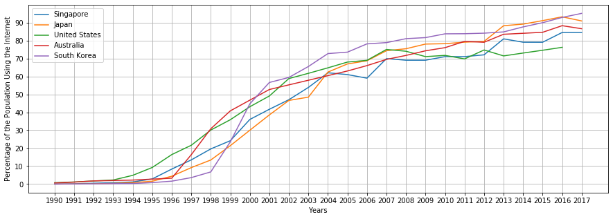

```python
df_internet = pd.read_csv('share-of-individuals-using-the-internet.csv').set_index('Year')

#These are countries i want to focus on
focus_countries = np.array(['Singapore','Japan','United States','Australia','South Korea'])

#Settings
plt.figure(figsize=(15, 5))
plt.xticks(np.arange(1990,2018,1))
plt.yticks(np.arange(0,110,10))
plt.xlabel("Years")
plt.ylabel("Percentage of the Population Using the Internet")
plt.grid()

#Plotting
for x in focus_countries:
    plt.plot(df_internet[df_internet.loc[:,"Entity"] == x]["Individuals using the Internet (% of population) (% of population)"],label=x)

plt.legend()
plt.show()
```

In conclusion, the internet went 'mainstream' in 2000 in most countries.

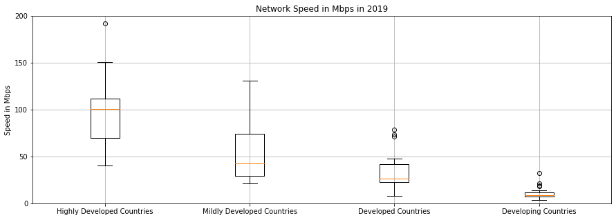

```python
df_internet_speed = pd.read_csv('internet_speed.csv').set_index('country').drop(columns="pop2020")


Highly_Developed_arr = np.array(['Norway','Switzerland','Ireland','Germany','Hong Kong','Australia','Iceland','Sweden','Singapore','Netherlands','Denmark','Finland','Canada','New Zealand','United Kingdom','United States','Belgium','Liechtenstein','Japan','Austria','Luxembourg'])#top 20
Mildy_Developed_arr = np.array(['Portugal','Qatar','Chile','Brunei','Hungary','Bahrain','Croatia','Oman','Argentina','Russia','Belarus','Kazakhstan','Bulgaria','Montenegro','Romania','Barbados','Kuwait','Uruguay','Turkey','Bahamas','Latvia'])#top40-60
Developed_arr = np.array(['Malaysia','Seychelles','Serbia','Trinidad and Tobago','Iran','Mauritius','Panama','Costa Rica','Albania','Georgia','Sri Lanka','Cuba','Saint Kitts and Nevis','Antigua and Barbuda','Bosnia and Herzegovina','Mexico','Thailand','Grenada','Brazil','Colombia'])#60-80
Developing_arr = np.array(['Afghanistan','Djibouti','Malawi','Ethiopia','Gambia','Haiti','Liberia','Yemen','Senegal','DR Congo','Mozambique','Sierra Leone','Burkina Faso','Benin','Mali','Burundi','Sudan','Madagascar','Mauritania','Niger'])#last 20

#Creating Sorting Information
Highly_Developed_internet = df_internet_speed[df_internet_speed.index.isin(Highly_Developed_arr)]['broadbandSpeed']

Mildy_Developed_internet = df_internet_speed[df_internet_speed.index.isin(Mildy_Developed_arr)]['broadbandSpeed']

Developed_internet = df_internet_speed[df_internet_speed.index.isin(Developed_arr)]['broadbandSpeed']

Developing_internet = df_internet_speed[df_internet_speed.index.isin(Developing_arr)]['broadbandSpeed']

#Stacking them together
totalArr = (np.vstack([Highly_Developed_internet,Mildy_Developed_internet,Developed_internet,Developing_internet]))

plt.figure(figsize=(15, 5))
plt.title("Network Speed in Mbps in 2019")
plt.ylabel("Speed in Mbps")
plt.yticks(np.arange(0,250,50))
plt.ylim(0)

plt.boxplot(totalArr.T,widths=0.2,labels=["Highly Developed Countries","Mildly Developed Countries","Developed Countries","Developing Countries"])
plt.grid()
plt.show()
```

From the graph, we can see that, obviously, Highly Developed Countries outclasses all the other groups. But it seems some countries in the Highly Developed Countries are still below 50 Mbps.  
The Mildy Developed Countries and Developed Countries are still close in terms of speed.  
It also seems that Developing countries have abyssmal internet speeds when compared to the Highly Developed Countries.  
This may be due to the fact that the Countries with more development have more money to support infrastructure for higher internet speeds when there is a breakthrough in internet speeds.  
Countries with less development cannot afford to spend money on internet infrastructure when their priority is, for example, Healthcare.  
In Conclusion, there is a trend between HDI and internet speed, however, it is not a absolute factor as some of the developed countries have faster internet speeds than the Mildly Developed Countries.  
The difference between Highly Developed and developing is big in terms of internet speeds, however, while there is an obvious trend, it should not be assumed that if a country is developing or has low HDI, it has low internet speeds as some countries defy this trend and have internet speed that does not fit the trend.

Now, this study will focus on Singapore.  
Singapore has been trying to be a smart nation, for example using an app for contract tracing during the COVID-19 Crisis [https://www.tracetogether.gov.sg/] and focusing on being a Smart Nation Through the Smart Nation Initiative.[https://www.smartnation.gov.sg/].  
Singapore also boasts the one of the highest broadband internet Speeds in the world, has the infrastructure to support a highly skilled tech nation and is in a good position to host servers to the rest of South East Asia.  
The bottom 2 graphs will expose how the internet age has changed Singapore and its population and answer the following questions.  
**Which age group uses more internet and when was the period with the most internet usage growth.**

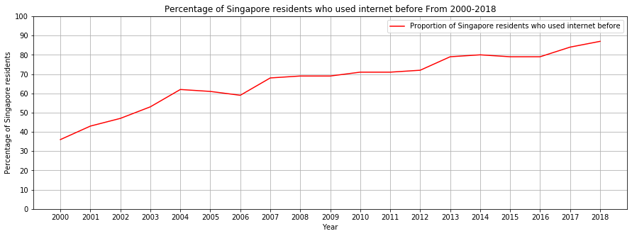

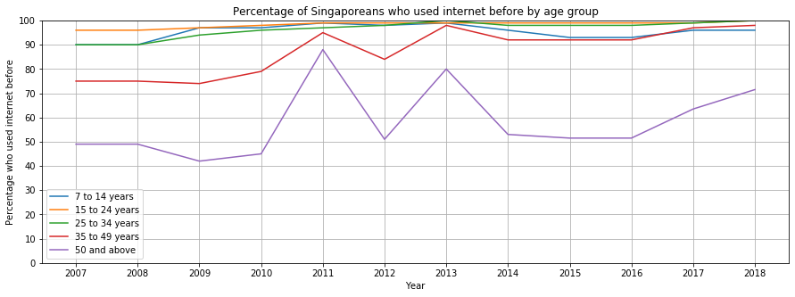

```python
df_IIU = pd.read_csv('individual-internet-usage.csv').set_index('year')

#Setting
plt.figure(figsize=(15, 5))
plt.xticks(np.arange(2000,2019,1))
plt.yticks(np.arange(0,110,10))
plt.ylim(0)
plt.title("Percentage of Singapore residents who used internet before From 2000-2018")
plt.xlabel("Year")
plt.ylabel("Percentage of Singapore residents")
plt.grid()

#Plotting
plt.plot(df_IIU,color='red',label="Proportion of Singapore residents who used internet before")
plt.legend()
plt.show()

#Setting
plt.figure(figsize=(15, 5))
plt.xticks(np.arange(2000,2019,1))
plt.yticks(np.arange(0,110,10))
plt.ylim(0)

df_IndividualInternetUsage = pd.read_csv('individual-internet-usage-by-age.csv').set_index('year')

#Replacing all of the 50-59 and 60 and above to "50 and above" to be .groupby'ed later.
df_IndividualInternetUsage_replaced = df_IndividualInternetUsage.replace(["50 to 59 years","60 and above"],"50 and above")

#I first reset_index to get the year,which is the index.
#I then Group the "50 and above" that was changed earlier, into 1 row and get the mean.
#I also group'd by year and set Sort to false to preserve the order. I then re set the year.
df_IndividualInternetUsage_reformat = df_IndividualInternetUsage_replaced.reset_index().groupby(by=["age","year"],sort=False).mean().reset_index().set_index('year')

#Plotting, I plotted by each age group.
for x in df_IndividualInternetUsage_reformat.groupby(by='age',sort=False).sum().index:
    plt.plot(df_IndividualInternetUsage_reformat[df_IndividualInternetUsage_reformat.iloc[:,0] == x].loc[:,"internet_usage"],label=x)

plt.legend()
plt.grid()
plt.title("Percentage of Singaporeans who used internet before by age group")
plt.xlabel("Year")
plt.ylabel("Percentage who used internet before")
plt.show()
```

From the first graph, we can see that the proportion of Singaporeans that have used internet before skyrockets from 2000-2004 going from below 40% to around 60%.  
There is some stagnation,decreases and slight increases from here to 2012. However, from 2013 onwards, there is a large increase in the amount of people using the internet. This could be due to the intorudction of smart nation in 2014, and in 2017 when the government dedicated 2.4 Billion to this initiative.

In the second graph, we can see that majority of the people have used internet before are those that are 34 years and less of age. Those who are 35 and above are consistently lower than their peers in 2007, however, after 2007, the 35-49 age group increases to where the only outlier is the 50 and above group. This may be due to the fact that they are forced to learn about and use the internet in order to be useful in the workforce or simply as it is a new technology that everybody else is using. A commonality in all of the years is that the 50 and above are below the rest. This has started to change however, in 2017 there was a large increase from the past year and 2018 has the same trend. This could be due to the fact that they realize that technology is overtaking old-fashioned methods and want to adapt.

In conclusion, in most of the years, the 7-34 year olds have used internet the most, along with 35-49 year olds past 2016. The period with the most internet growth is 2000-2004, a close second would be 2013-2018.

We should also look at what kind of broadband connection most users have at the time. It represents how fast their internet speeds can possibly be. A fibre internet connection can reach up to 2 Gbps while a wired internet is usually around 96 Mbps. A fast internet connection allows more data be streamed or sent to the internet. A question we can answer here is,  
**What type of broadband connection became the most dominant at what time and why?**

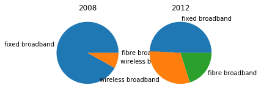

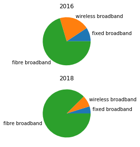

```python
df_internet_type = pd.read_csv('internet-connection-at-home-by-type.csv').set_index('year').replace({"na":0})

plt.subplot(1,2,1)
plt.title(2008)
fig = plt.gcf()
fig.set_size_inches(5,5)
plt.pie(df_internet_type[df_internet_type.index.isin([2008])].loc[:,"internet_access"],labels=pd.unique(df_internet_type.loc[:,'type_of_connection']))

plt.subplot(1,2,2)
plt.title(2012)
fig = plt.gcf()
fig.set_size_inches(5,5)
plt.pie(df_internet_type[df_internet_type.index.isin([2012])].loc[:,"internet_access"],labels=pd.unique(df_internet_type.loc[:,'type_of_connection']))
plt.show()

plt.subplot(2,1,1)
plt.title(2016)
fig = plt.gcf()
fig.set_size_inches(5,5)
plt.pie(df_internet_type[df_internet_type.index.isin([2016])].loc[:,"internet_access"],labels=pd.unique(df_internet_type.loc[:,'type_of_connection']))

plt.subplot(2,1,2)
plt.title(2018)
fig = plt.gcf()
fig.set_size_inches(5,5)
plt.pie(df_internet_type[df_internet_type.index.isin([2018])].loc[:,"internet_access"],labels=pd.unique(df_internet_type.loc[:,'type_of_connection']))
plt.show()
```

So from this graph, we can see that in 2008 Fixed broadband is the dominant segment in the industry with a small amount of Wireless broadband.

In 2012, Fixed broadband was still in the majority, with Fibre and Wireless holding around 25% each. The small amount of Fibre could be that it is a new technology at this point as it was introduced to Singapore in September 2010.  
Source:https://en.wikipedia.org/wiki/Internet_in_Singapore

In 2016, Fibre is now in the majority holding around 70%. This is probably due to the fact that Fibre is faster, has less latency, and is probably the best option among the 3. However, Fibre takes a long time to install compared to Wired.(1-2 Weeks compared to 3-5 Days)This could be the reason why fibre has not completely made Fixed broadband obselete.

In conclusion, Fibre is now the dominant Connection type in Singapore, overtaking fixed broadband around 2012-2016 due to its advantages of being faster. Before 2016, the majority would be fixed broadband. This means Majority of Singaporeans have access to 1gbps or more internet speeds as fiber supports 1gbps+ connections.

Now, we must answer the question,  
**How has the rise of the internet affected the Singaporean Economy, specifically the info-comm industry?**  
This question will be answered in a series of graphs.  
For our first graph, we shall view the number of infocomm jobs per year.

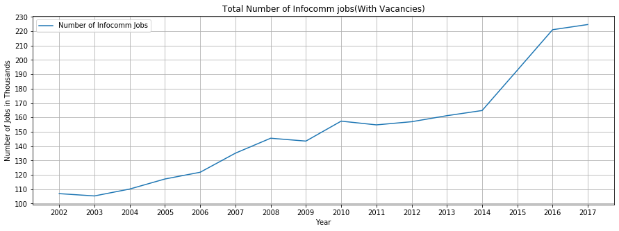

```python
df_IIU = pd.read_csv('number-of-infocomm-jobs-employed-and-vacancies.csv').set_index("year").astype(int)

#Setting
plt.figure(figsize=(15, 5))
plt.xticks(np.arange(2002,2018,1))
plt.yticks(np.arange(100,250,10))
plt.grid()
plt.ticklabel_format(style = 'plain')
plt.xlabel("Year")
plt.ylabel("Number of Jobs in Thousands")
plt.title('Total Number of Infocomm jobs(With Vacancies)')

#Plotting, I divided all by a thousand to make the numbers easier to read.
plt.plot(df_IIU/1000,label="Number of Infocomm Jobs")
plt.legend()
plt.show()
```

From the graph, we can see that the overall, the number of infocomm jobs has doubled over the years from 110k to 225k. Notable periods of time are 2014-2016 where there is a large increase from 165k to 220k. This may be due to the SmartNation initiative. Otherwise, there is a slight increase of around 5k-10k per year.To conclude this graph, the rise of the information age has provided Singapore with more jobs and thus a better economy.

Now we move onto how it has affected education.  
I will be looking into the university intake statistics related to Information Technology.

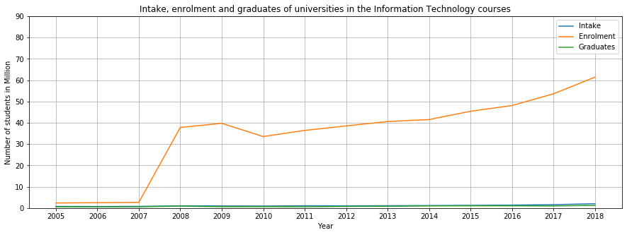

```python
df_uni = pd.read_csv('universities-intake-enrolment-and-graduates-by-course.csv').set_index('year')

#Get all Information Technology students, group them by year and sum them together to add the genders together, then drop the useless columns.
df_uni_group = df_uni[df_uni.loc[:,"course"] == 'Information Technology'].groupby(['year']).sum().drop(columns=(["sex","course"]))

#Use this to get rid of the "," when the number is too high.
df_uni_reformat = df_uni_group.replace({',':''}, regex=True)

#This is to capitalize the columns to make them more user-friendly
df_uni_reformat.columns = df_uni_reformat.columns.str.capitalize()

#Setting
plt.figure(figsize=(15, 5))
plt.xticks(np.arange(2000,2019,1))
plt.yticks(np.arange(0,100,10))
plt.grid()
plt.ylim(0)
plt.ticklabel_format(style = 'plain')
plt.xlabel("Year")
plt.ylabel("Number of students in Million")
plt.title('Intake, enrolment and graduates of universities in the Information Technology courses')

#Plotting
for x in df_uni_reformat.columns:
    plt.plot(df_uni_reformat.loc[:,x].astype('int')/1000000,label=x)

plt.legend();
plt.show();
```

There could be some reasons why even though enrolment is increasing, the Intake or Graduates are not. This could be due to the Singaporean government keeping standards high for graduates:https://international.thenewslens.com/article/68084, or some other reasons.

The large increase in enrolment could be attributed to the increasing popularity of Information Technology as a job. Most of the people probably applying grew up with the internet and thus want to pursue a higher education in something they enjoy. To conclude this graph,The rise of the internet has helped to increase the amount of skilled labour able to work in the Singaporean infocomm industry.

Now we will look at what exactly the infocomm industry in Singapore looks like.  
The following graphs should give us a good perspective on the industry.

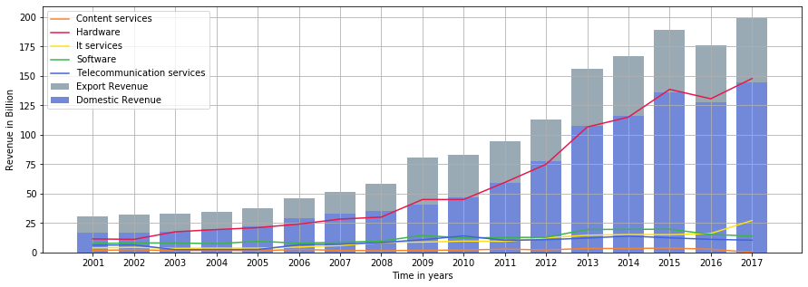

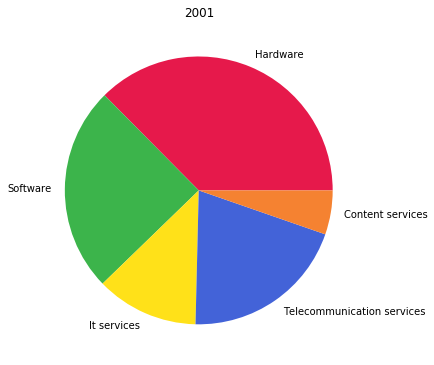

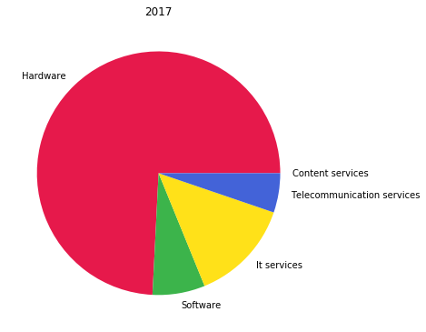

```python
def sort_func(x,loc):
    return df_total[df_total.index == np.unique(df_total.index)[x]].loc[:,loc]

df_export = pd.read_csv("export-revenue-of-infocomm-industry-by-market-segment.csv").set_index("year")
df_domest = pd.read_csv("domestic-revenue-of-infocomm-industry-by-market-segment.csv").set_index("year")

#Select Colours
coloring = ["#E6194B", "#3CB44B", "#FFE119", "#4363D8", "#F58231"]

#Rename and Replace data to make it compatible with its counterpart.
df_domest_rename = df_domest.rename(columns={'market_segment':'segment'}).replace(["it_services","telecommunication_services","content_services"], ["it services","telecommunication services","content services"])

#Capitalize to make it look nicer.
df_export['segment'] = df_export['segment'].apply(lambda x: x.capitalize())
df_domest_rename['segment'] = df_domest_rename['segment'].apply(lambda x: x.capitalize())

#Merge the Datasets into 1 after cleaning.
df_total = pd.merge(df_export,df_domest_rename,on=["segment","year"])
df_total['total_revenue'] = df_total['export_revenue'] + df_total['domestic_revenue']

#Adding Color Column
df_total['color'] = df_total['segment'].map({'Hardware':"#E6194B", "Software":"#3CB44B", "It services":"#FFE119", "Telecommunication services":"#4363D8", "Content services":"#F58231"})

#Made it into 1 line
df_total_sort_by_year = df_total.groupby(by='year').sum()

#These were the old graphs that were seperated. This will remain here incase i need access to them.

#Setting
# plt.figure(figsize=(15, 5))
# plt.grid()
# plt.xticks(np.arange(2001,2018,1))
# plt.xlabel("Time in years")
# plt.ylabel("Revenue in Billion")
# plt.title("Total Revenue Seperated by Domestic or Foreign")

# #Plotting
# plt.bar(np.arange(2001,2018,1),df_total_sort_by_year.loc[:,"domestic_revenue"],align='center',color='#99aab5', alpha=1,width=.75,label="Export Revenue",bottom=df_total_sort_by_year.loc[:,"export_revenue"])
# plt.bar(np.arange(2001,2018,1),df_total_sort_by_year.loc[:,"export_revenue"],align='center',color='#7289da', alpha=1,width=.75,label="Domestic Revenue")
# plt.legend()
# plt.show()

# #Get array of the segments
# df_segments = df_total.groupby("segment").sum().index

# #Setting
# plt.figure(figsize=(15, 5))
# plt.xlabel("Time in years")
# plt.ylabel("Revenue in Billion")
# plt.ylim(0)
# plt.yticks(np.arange(0,225,25))
# plt.xticks(np.arange(2001,2018,1))
# plt.title("Total Revenue by Segment")
# plt.grid()

# #Plotting
# #For loop to get each segment plotted, for their total revenue
# for x in df_segments:
#     plt.plot(df_total[df_total["segment"].isin([x])]['total_revenue'],label=x,color=df_total[df_total["segment"] == x]['color'].iloc[0])

# plt.legend()
# plt.show()


#Get array of the segments
df_segments = df_total.groupby("segment").sum().index

#Fusion Graph Setting
plt.figure(figsize=(15, 5))
plt.grid()
plt.xticks(np.arange(2001,2018,1))
plt.xlabel("Time in years")
plt.ylabel("Revenue in Billion")

#Fusion Graph Plotting


#Get Color from Color column.

#Get label from the for-loop

#Plotting the Line graph
for x in df_segments:
    plt.plot(df_total[df_total["segment"] == x]['total_revenue'],label=x,color=df_total[df_total["segment"] == x]['color'].iloc[0])

#Plotting the Bar Graph
plt.bar(np.arange(2001,2018,1),df_total_sort_by_year.loc[:,"domestic_revenue"],align='center',color='#99aab5', alpha=1,width=.75,label="Export Revenue",bottom=df_total_sort_by_year.loc[:,"export_revenue"])
plt.bar(np.arange(2001,2018,1),df_total_sort_by_year.loc[:,"export_revenue"],align='center',color='#7289da', alpha=1,width=.75,label="Domestic Revenue")
plt.legend()
plt.show()

#Pie chart in 2017
fig = plt.gcf()
fig.set_size_inches(6,8)
plt.pie(df_total[df_total.index == 2001]['total_revenue'],colors=df_total[df_total.index == 2001]['color'],labels=df_total[df_total.index == 2001]['segment'])
plt.title(np.unique(df_total.index)[0])
plt.show()

#Pie chart in 2001
fig = plt.gcf()
fig.set_size_inches(6,8)
plt.pie(df_total[df_total.index == 2017]['total_revenue'],colors=df_total[df_total.index == 2017]['color'],labels=df_total[df_total.index == 2017]['segment'])
plt.title(np.unique(df_total.index)[-1])
plt.show()
```

The second graph is a line graph depicting most of the market-segments throughout the years. From this graph, we can see that the Hardware revenue accounts for most of our revenue. We can also see the rise of Hardware dominating the total revenue starting in 2008 to 2017. We also see that the rest of the market-segments are stagnant, they did not change a lot when compared to the changes in Hardware.

As for the pie charts,they are meant to compare how much they emphasize how prominent the hardware market-segment is, even in 2001. In 2001, it accounted for around 40% of the total revenue. While in 2017, it accounts for 75% of the total revenue. It also shows the decline of the content services . In 2001, it was a small chunk of the revenue, while 2017 it has no reported revenue.

To answer the question posed at the start of this section,  
**How has the rise of the internet affected the Singaporean Economy?**  
As evidenced, in the graphs above, the rise of the internet has benefitted the economy very well. Revenue has increased along ith the size of their sectors. More jobs and students that want to study in the industry which will lead to more jobs. This means that the economy is growing very fast and will continue to grow as students will fill the job market. Most of the industries that increased have reported a large, at least a 100% increase, in their revenue or equivalent.

Now we will focus on a related topic. The rise of the mobile phone along with mobile data and its ability to access internet. This allows us all the advantages of the internet while remaining mobile. The question we will be attempting to answer using the graph is  
**How has the rise of the internet affected the amount of mobile phones, and what might be the reason why?**  
This graph shows the Number of Mobile phone subscriptions. Note that some people may have multiple phones.

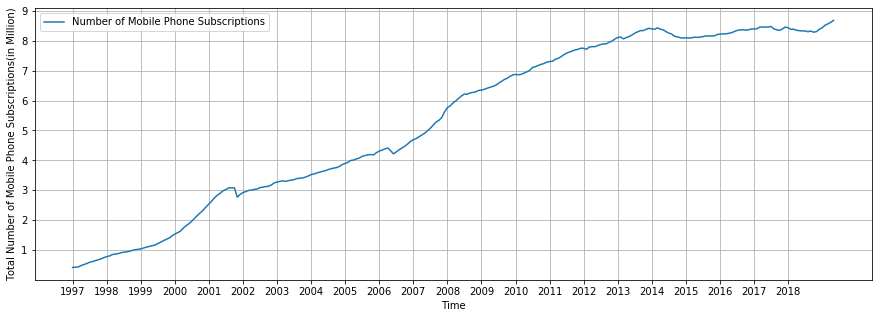

```python
df_mobile_sub = pd.read_csv("total-mobile-phone-subscriptions.csv").set_index("month")

df_mobile_sub_unique_index = np.arange(1997,2020)

#Setting
plt.figure(figsize=(15, 5))
plt.xlabel("Time")
plt.ylabel("Total Number of Mobile Phone Subscriptions(in Million)")
plt.yticks(np.arange(0,10,1))
plt.xticks(np.arange(0,264,12),df_mobile_sub_unique_index)
plt.grid()

#Plotting
plt.plot(df_mobile_sub/1000000,label="Number of Mobile Phone Subscriptions")
plt.legend()
plt.show()
```

From this graph, we can see that in 1997, there was only half a million people owning phones, while in 2018, if we dont account for people owning multiple phones, there are over 8 million phones meaning that everybody has a phone.There is a increasing trend for most of the years from 1997 to 2014, from 2014 to the later half of 2018 there is little or no increase, just stagnating around 8 Million.  
My theory is that most of the people that can afford a phone already had one, and those that can or need 2 or more phones already had them, therefore there is no increase.  
In Conclusion, Mobile Phones have become an important part of our lives such that mobile phones outnumber the singaporean population by 3 Million, this is likely due to their portability and ability to function as mobile computers. This is shown through their massive increase throughout the years.

As we know, mobile phones can accomplish a multitude of tasks. We can answer the question,  
**What do Singaporeans do with their mobile phones, how has that changed over the years and what generation uses mobile phones the most.**  
We will do this with this modified pie chart. Note that the sample size includes people who ever used a mobile device for media activities.

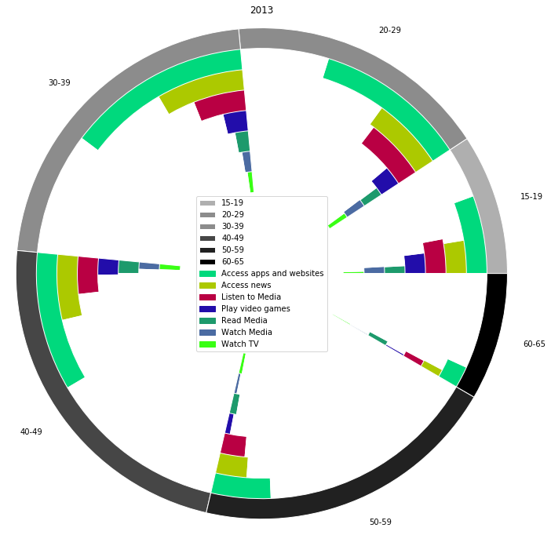

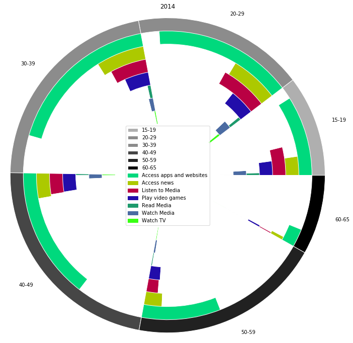

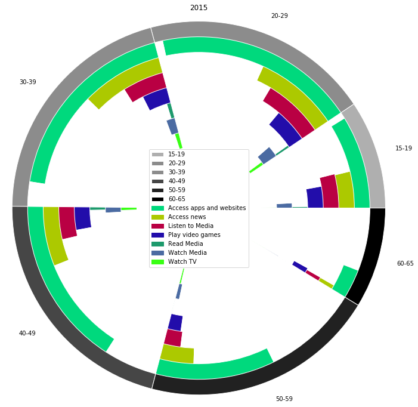

```python
import matplotlib.patches as mpatches

def pie_age(x,unique_val):
    return pd.unique(df_devices_rename[df_devices_rename.index.isin([x])].loc[:,unique_val])
def pie_seg(x):
    return df_devices_rename[df_devices_rename.index.isin([x])].groupby(by=["media_activity",'age','year','sample_size']).mean().sort_values(["age","media_activity"])

df_devices = pd.read_csv("usage-of-mobile-devices-for-media-activities.csv").set_index('year')
coloring = ["#AFAFAF","#8C8C8C","#8C8C8C","#464646","#212121","000000"]
coloring_act = ['#00D97D','#ACC900','#B90043','#220DAA','#1D9A6C','#4B6BA2',"#39ff14"]

#Rename certain acitivities to make the graph less cluttered later
df_devices_rename = df_devices.replace(["Watch MediaCorp TV","Watch Singtel TV","Watch StarHub TV"], "Watch TV").replace(["Access non-media-related apps and websites","Access media-related apps and websites"],"Access apps and websites").replace(['Watch videos','Watch movies','Watch animation'],"Watch Media").replace(['Listen to music','Listen to the radio'],"Listen to Media").replace(['Read books','Read magazines'],"Read Media")

df_devices_rename['total'] = df_devices_rename['sample_size']*(df_devices_rename['ever_used']/100)

df_devices_rename['difference'] = df_devices_rename['sample_size'] - df_devices_rename['total']

#Iterates through years.
for y in np.unique(df_devices.index):
    df_devices_rename_segments = pie_seg(y)[['total','difference']].to_numpy().flatten()

    #Plotting
    plt.pie(pie_age(y,"sample_size"),radius=1.2,wedgeprops=dict(width=0.3, edgecolor='w'),colors=coloring,labels=pie_age(y,"age"))

    #Plots for each section
    y1 = 0

    for x in enumerate(coloring_act):
        plt.pie(df_devices_rename_segments[[y1,y1+1,y1+14,y1+15,y1+28,y1+29,y1+42,y1+43,y1+56,y1+57,y1+70,y1+71]],radius=1.1-y1/20,wedgeprops=dict(width=0.3, edgecolor='w'),colors=[x[1],'white'])
        y1 += 2

    #This handles the middle circle
    centre_circle = plt.Circle((0,0),0.4,color='black', fc='white',linewidth=0)
    plt.title(y)
    fig = plt.gcf()
    fig.set_size_inches(12,12)
    fig.gca().add_artist(centre_circle)

    #Add custom Legend, Manually Add the legend so as to not clutter it.
    plt.legend()
    handles, labels = plt.gca().get_legend_handles_labels()

    #This changes the Legend to be something more clean
    for i in enumerate(coloring_act):
        handles.append(mpatches.Patch(color=i[1], label=df_devices_rename.groupby(by='media_activity').sum().index[i[0]]))

    plt.legend(handles=handles,loc='center')
    plt.show()
```

From the graph, we can see that the main thing is that people of all age groups most of the time use Mobile phones to access applications and websites. It accounts for most of the usage of mobile phones. A second would be Accessing news or Listening to Media. However, the segment "Access apps and websites" is very ambigious.

A interesting difference between years is that the 60-65,50-59 age groups both have reported increased use of the mobile device to Access apps and websites segments in 2015 compared to 2013. This could be due to them being educated by their peers on how to utilize their devices to their full potential.

There is also differences between ages. In 2013, the 60-65 age group has little to no "Play Video Games" segment and a relatively large amount of "Access news" Segment compared to the 15-19 age group which has a relatively large "Play Video Games" segment and smaller "Watch TV" Segment. This could be due to the fact that most 60-65 year olds do not play video games and rely on old methods such as newspapers or the Television where it is different in the 15-19 year old age group.

In conclusion, This graph tells me that as time goes on, more people use mobile phones for apps and websites than other functions. Although the segment "Access apps and websites" is very ambiguous and could mean anything, it is constantly the largest part of the graph.

The graphs also finds that the from 2013-2015, more people access apps and websites compared from 2013 to 2015.For example, only a small amount of 50-59 aged people used their phone for apps and websites while in 2015, there was a significantly large amount that used their phone for apps and websites.

This graph also finds that most of the people who uses mobile phones are between 15-49, however, an increasingly large part of the population that is above 50 also accounts for phone usage from 2013 onwards.

To summarize the study up, The internet has provided countries a way to increase their productivity and their GDP per capita. This is supported by a scatterplot where a trend was found in where high GDP per capita countries are also the ones with high internet access.

A related sub-development are mobile phones, mobile phone subscriptions went from 0.5 Million to 8 Million at the end of 2018. Most people who use mobile phones are between 15-40 years of age, however this is changing.